# Modeling Occupancy and Abundance

prepared by: *Michael T. Hallworth*  
*Smithsonian Conservation Biology Institute : Migratory Bird Center*

## Introduction

Point count data are a cost effective way of surveying large areas to answer ecological questions. For example, point count data can answer the questions:

- How many species are present in a given area?
- How many individuals of each species are there?
- How has the community changed over time?
- Which habitats is X species associated with?

These are just a few of the possible questions that can be answered using point count data. However, the question of interest determines how the data should be analyzed. If the question deals with *how many species are present here?* then using occupancy modeling would be a good fit. If the question is something like *How has the population size of Ovenbirds changed over time?*, then modeling abundance is more appropriate.

Regardless of the question - accounting for imperfect detection is important. Failing to account for imperfect detection biases estimates of either species richness or abundance low - unless all species and/or individuals are detected perfectly. This is unlikely given that the study organisms are animals and move, may have been siting on a nest during your visit, preening instead of singing, etc.

**NOTE:** The code was written for analysis using BUGS language (JAGS, winBUGS, openBUGS, etc.)

The MCMC sampler used in this example is [JAGS](https://sourceforge.net/projects/mcmc-jags/files/).

## Install JAGS & packages

If you’re interested in conducting Occupancy modeling or estimating Abundance in JAGS, install JAGS then run the following code to get the packages needed for the tutorial. JAGS (Just Another Gibbs Sampler) can be downloaded [here](https://sourceforge.net/projects/mcmc-jags/files/).

```r
# Check to make sure the required packages are installed on your machine
# If not, they will be installed

reqPackages <- c("RCurl","rjags","jagsUI","raster","sp","maptools","rgeos","MASS")
get.packages <- reqPackages[!(reqPackages %in% installed.packages()[,"Package"])]
if(length(get.packages)>0) install.packages(get.packages,dependencies = TRUE)
```

```r
library(raster)
library(RCurl)
library(jagsUI)
```

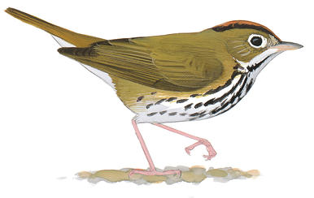

## Occupancy

Occupancy modeling is done using hierarchical models. You can think of occupancy as two processes. The observation model and the process model or ecological model. Often times we are interested in the ecological or process model but it really depends on the question of interest. The true occupancy state of a plot or location is a latent variable - can’t be observed directly in the presence of imperfect detection. To estimate the occupancy state ($Z$) we use a combination of the observation model and ecological or process model.

*Observation model*

$y_{ij} \mid Z_i \sim Bernoulli(Z_i*\rho)$

where $y$ is the observation of detection/non-detection (1/0) at site $i$ and replcate $j$ given the true occupancy state ($Z$) at site $i$. $\rho$ is the probability of detecting the species given that it is present. We can model changes in detection probability ($\rho$) as a function of covariates ($x$) using a linear model with a logit link function.

$logit(\rho) = \alpha + \beta*x$

*Process model*

$Zi \sim Bernoulli(\psi_i)$ $logit(\psi_i) = \alpha + \beta*x_i$

We can include variables of interest in both the Observation and Process / Ecological model. For example, when conducting avian point counts the time of day, or date of the survey may be an important variables in the Observation model but may not contribute to true occupancy state of a site. The reverse is also true, elevation may be an important variable in whether Ovenbirds occupy a site but may have little or no influence on your ability to detect them. Having both an Observation and process/ecological model allows one to disentangle these factors.

### Writing out the model

Let’s write out a simple occupancy model using algebra before we write the model in BUGS language. For this example we will use simulated point count data from Hubbard Brook Experimental Forest, NH. We conducted point counts at 373 locations throughout HBEF during the 2015 breeding season. We used a robust-design where each location was surveyed at least 3 times during the breeding season (a time in which the occupancy state does not change). During 2015 we conducted 10-min point counts at each surveyed each location 4 times throughout the season. We recorded the Date (`Date`), time (`Time`) the survey started and who conducted the survey (`Obs`). We are ultimately interested in what factors influence Ovebird occupancy throughout the HBEF. At each site, we recorded elevation (`Elev`), slope (`Slope`) and Aspect (`Aspect`) because we thought these variables may be important in determining whether Ovenbirds are present or not.

### Exercise:

> Take a minute or two and think about how you would write out a model using the covariates described above. Be sure to include the distribution of any parameters included in the model, $\beta$ for example.

Let’s write out a model with all the covariates. Here we will allow detection ($\rho$) to vary by survey location $i$ by incorporating variables we think are important for detection and change by survey replicate $j$.

**Observation Model**

$y_{ij} \mid Z_i \sim Bernoulli(Z_i*\rho_i)$

$logit(\rho_i) = \alpha + \beta_1*Date_{ij}+\beta_2*Time_{ij}+\beta_3*Obs_{ij}$

**Process / Ecological Model**

$Z_i \sim Bernoulli(\psi_i)$

$logit(\psi_i) = \alpha + \beta_1*Elev_i + \beta_2*Slope_i + \beta_3*Aspect_i$

**Distribution of parameters in model**

$\beta \sim Normal(\mu,variance)$ $\alpha \sim Normal(\mu, variance)$

## Getting the data

```r
# Define the location of the data on GitHub
data_url <- "https://raw.githubusercontent.com/MTHallworth/OccAbun_Buler/master/data/OVEN.csv"

SiteCovs_url <- "https://raw.githubusercontent.com/MTHallworth/OccAbun_Buler/master/data/SiteCovariates.csv"
Date_url <- "https://raw.githubusercontent.com/MTHallworth/OccAbun_Buler/master/data/Date.csv"
Time_url <- "https://raw.githubusercontent.com/MTHallworth/OccAbun_Buler/master/data/Time.csv"
Observer_url <- "https://raw.githubusercontent.com/MTHallworth/OccAbun_Buler/master/data/Obs.csv"

# Get the data connection using RCurl
data.url <- getURL(data_url)
covs.url <- getURL(SiteCovs_url)
date.url <- getURL(Date_url)
time.url <- getURL(Time_url)
obs.url <- getURL(Observer_url)

# Read in the data
OVEN <- read.csv(textConnection(data.url))
SiteCovs <- read.csv(textConnection(covs.url))
Date <- read.csv(textConnection(date.url))
Time <- read.csv(textConnection(time.url))
Obs <- read.csv(textConnection(obs.url))

Time[is.na(Time)]<-0
Date[is.na(Date)]<-0
Obs[is.na(Obs)]<-0

# Rename the first column in SiteCovs from X to Plot
names(SiteCovs)[1]<-"Plot"
names(Date) <- c("Rep.1","Rep.2","Rep.3","Rep.4")
names(Time) <- c("Rep.1","Rep.2","Rep.3","Rep.4")
names(Obs) <- c("Rep.1","Rep.2","Rep.3","Rep.4")

# Inspect first 5 rows
head(OVEN)
```

```
##   OVEN_0 OVEN_1 OVEN_2 OVEN_3
## 1      0      2      0      4
## 2      0      2      1      3
## 3      0      2      0      0
## 4      0      2      1      0
## 5      0      2      1      3
## 6      0      0      1      5
```

The number of individuals were counted within the 10min point count. Here we convert the number of individuals to presence / absence.

```r
OVENocc<-OVEN
OVENocc[OVENocc>1]<-1

head(OVENocc)
```

```
##   OVEN_0 OVEN_1 OVEN_2 OVEN_3
## 1      0      1      0      1
## 2      0      1      1      1
## 3      0      1      0      0
## 4      0      1      1      0
## 5      0      1      1      1
## 6      0      0      1      1
```

## Specifying the model in BUGS language

```r
###################################################################################
#
# Specify model in BUGS language
#
###################################################################################

cat("
model {
###################################################################################
#
#             Priors
#
###################################################################################
# Hyperpriors
mu.lpsi ~ dnorm(0,0.01)        # Intercept psi
sd.lpsi ~ dunif(0,8)           # std priro intercept psi
tau.lpsi <- pow(sd.lpsi, -2)   # precision intercept psi

mu.beta ~ dnorm(0,0.01)        # Prior for psi beta estimates
sd.beta ~ dunif(0,5)           # std for psi beta estimates
tau.beta <- pow(sd.beta, -2)   # precision psi beta estimates

mu.lp ~ dnorm(0,0.01)          # Intercept p
sd.lp ~ dunif(0,3)             # std prior p
tau.lp <- pow(sd.lp, -2)       # precision intercept p

mu.betaP ~ dnorm(0,0.01)       # Prior for p beta estimates
sd.betaP ~ dunif(0,3)          # std for p beta estimates
tau.betaP <- pow(sd.betaP, -2) # Precision for p beta estimates

# priors
   lpsi ~ dnorm(mu.lpsi, tau.lpsi) # Intercept for psi using Hyperparams
   lp ~ dnorm(mu.lp, tau.lp)       # Intercept for p using Hyperparams

for(c in 1:ncovs){                      # Occupancy Covs
   beta[c] ~ dnorm(mu.beta, tau.beta)   # prior for psi beta using hypers
 } #ncovs

for(d in 1:pcovs){                       # Detection Covs
   betaP[d] ~ dnorm(mu.betaP, tau.betaP) # prior for p beta using hypers
}  #pcovs


##################################################################################
#
# Likelihood
# Ecological model for true occurrence (process model)
#
##################################################################################

for (i in 1:plots) {

      logit(psi[i])<-lpsi +              # intercept psi
                     beta[1]*Elev[i] +   # beta for Elev
                     beta[2]*Elev2[i] +  # beta for Elev2
                     beta[3]*Slope[i] +  # beta for Slope
                     beta[4]*Aspect[i]   # beta for Aspect

      z[i] ~ dbern(psi[i])               # Occupancy state

} #nplots

##################################################################################
#
# Observation model for replicated detection/nondetection observations
#
##################################################################################

   for (i in 1:plots){
      for(j in 1:reps){

         logit(p[i,j]) <-lp +                  # Intercept for detection
                         betaP[1]*time[i,j] +  # beta for time
                         betaP[2]*date[i,j] +  # beta for date
                         betaP[3]*obsvr[i,j]   # beta for observer

         y[i,j] ~ dbern(z[i] * p[i,j])    # True Occupancy state * detection

      } #nreps
   }    #nschwarz

##################################################################################
#
# Derived quantities
#
##################################################################################

# No derived quantities yet

##################################################################################

} # End Model
",fill=TRUE,file = "model_files/Occupancy.txt")
```

Setting reasonable occupancy states as starting values. The model won’t run if you don’t set appropriate initial values for the occupancy state. If you don’t specify initial values for a variable JAGS will select a starting value. However, the initial value that JAGS selects for occupancy state may differ from the true occupancy state - in such cases JAGS reports an error. The error is typically `Invalid parent node`. To avoid that we need to set appropriate initial values. Here we write a function to do just that. We set occupancy to 1 if the species is ever recorded at the plot and 0 otherwise by using the apply function.

```r
zint<-function(x){
  b<-apply(x,1,sum)
  b[b>1]<-1
  return(b)
}
```

Here we pass JAGS a list of initial values - we call the list inits. Notice that the function we just made `zint` is executed within the list. This is important if we want to run the code in parallel.

```r
set.seed(04823)
inits <- function() list(z = zint(OVENocc),
                         mu.lpsi=rnorm(1,0,0.1),
                         sd.lpsi=runif(1,0,8),
                         mu.beta=rnorm(1,0.1),
                         sd.beta=runif(1,0,5),
                         mu.lp=rnorm(1,0,0.1),
                         sd.lp=runif(1,0,3),
                         mu.betaP=rnorm(1,0,0.1),
                         sd.betaP=runif(1,0,3))
```

Set the number of chains we want to run

```r
nchains<-3
```

Set up the data to be passed to JAGS. Notice the named list. The names in the list correspond to variables in the model.

```r
win.data <- list(y = OVENocc,
                 ncovs = 4,
                 pcovs = 3,
                 time = Time,
                 date = Date,
                 obsvr = Obs,
                 plots = 373,
                 reps = 4,
                 Elev = SiteCovs$Elevation,
                 Elev2 = (SiteCovs$Elevation*SiteCovs$Elevation),
                 Slope = SiteCovs$Slope,
                 Aspect = SiteCovs$Aspect)
```

Tell JAGS which parameters we want to save - be careful here to specify all the variables you want to monitor after the model runs it’s impossible to get information about a variable that is not monitored. This becomes extremely important when a model takes days or even weeks to run! Choose these carefully!

```r
parameters.to.save = c("psi","lpsi","beta","p","lp","betaP")
```

Next we send the model, data, and initial values to JAGS to run the analysis. Notice the different parameters that JAGS needs to run.

```r
a<-Sys.time()
z <- jags(model.file = "model_files/Occupancy.txt",  # File written in BUGS language
          data = win.data,              # Data to run the model on
          inits = inits,                # initial values
          parameters.to.save = parameters.to.save,   # parameters you want to monitor
          n.iter = 1000,                # number of iterations to run per chain
          n.burnin = 500,               # number of iterations to discard
          n.thin = 10,                  # save every 10th iteration reduces autocorrelation
          n.chains = 3,                 # number of chains to run
          n.adapt = 500,                # number of iterations to 'prime' the model
          parallel = TRUE)              # run in parallel or not
```

```
##
## Processing function input.......
##
## Converting data frame 'y' to matrix.
##
## Converting data frame 'time' to matrix.
##
## Converting data frame 'date' to matrix.
##
## Converting data frame 'obsvr' to matrix.
##
## Done.
##
## Beginning parallel processing with 3 clusters. Console output will be suppressed.
##
## Parallel processing completed.
##
## Calculating statistics.......
##
## Done.
```

```r
Sys.time()-a
```

```
## Time difference of 26.13506 secs
```

## Results

### Inside the output

The model results are stored in a named list. The iterations are stored in `sims.list` but `jagsUI` also calculates the `mean`, and credible intervals (q2.5,q97.5).

```r
str(z)
```

[output not shown]

### The all important figures

We can look at how elevation, elevation^2, slope and aspect influence Ovenbird occupancy within Hubbard Brook by looking at the beta estimates but everyone likes a nice figure. Here’s how you can make one of those. First we need to do a few things. We need to create a variable where we can predict occupancy using our modeled results. Let’s make a vector of elevation values that span the elevation at HBEF.

```r
# give me 1000 values in sequence from minimum elevation to maximum elevation
ElevationOcc <- seq(min(SiteCovs$Elevation),max(SiteCovs$Elevation),,1000)

EstOcc<-z$mean$lpsi+ # intercept
                z$mean$beta[1]*ElevationOcc + #the elevation layer
                z$mean$beta[2]*(ElevationOcc*ElevationOcc) +  # mean Elev2
                z$mean$beta[3]*0 +  # mean Slope
                z$mean$beta[4]*0  # mean Aspect

LCI.Occ<-z$q2.5$lpsi+ # intercept
                 z$q2.5$beta[1]*ElevationOcc+ #the elevation layer
                 z$q2.5$beta[2]*(ElevationOcc*ElevationOcc)  +  # mean Elev2
                 z$q2.5$beta[3]*0 +  # mean Slope
                 z$q2.5$beta[4]*0   # mean Aspect

UCI.Occ<-z$q97.5$lpsi+ # intercept
                z$q97.5$beta[1]*ElevationOcc + #the elevation layer
                z$q97.5$beta[2]*(ElevationOcc*ElevationOcc) +  # mean Elev2
                z$q97.5$beta[3]*0 +  # mean Slope
                z$q97.5$beta[4]*0   # mean Aspect
```

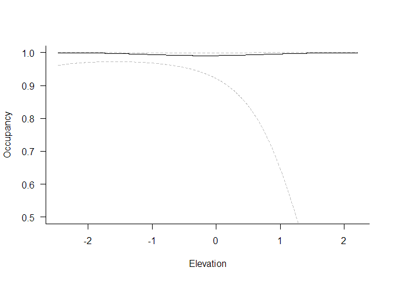

```r
par(bty="l")
plot(plogis(EstOcc)~ElevationOcc,
     type="l", # line graph instead of points
     yaxt="n", # don't print y axis text
     ylab="Occupancy",
     xlab="Elevation",
     ylim=c(0.5,1)) # set yaxis limits

axis(2,las=2) # print readable y axis text

#Plot upper and lower credible intervals
points(plogis(LCI.Occ)~ElevationOcc,
       type="l", #plot line not points
       lty=2, # dotted line
       col="gray") # gray line

points(plogis(UCI.Occ)~ElevationOcc,
       type="l", #plot line not points
       lty=2, # dotted line
       col="gray") # gray line
```

## Predictions on the landscape

We can make predictions on the landscape based on the model results.

### Grab values for HBEF landscape

```r
landscape_url<-"https://raw.githubusercontent.com/MTHallworth/OccAbun_Buler/master/data/HBEFgridcovs.csv"
landscape.url <- getURL(landscape_url)

# Read in the data
landscapeValues <- read.csv(textConnection(landscape.url))

head(landscapeValues)
```

```
##          x       y  Elevation    Aspect       Slope
## 1 274857.9 4866056 -0.3980050 0.8017219 -1.10143357
## 2 274907.9 4866056 -0.3729957 0.6123322 -0.81061823
## 3 274957.9 4866056 -0.3442296 1.0850015 -1.11563316
## 4 275007.9 4866056 -0.3196367 1.2999557 -0.87066134
## 5 275057.9 4866056 -0.2732631 1.0355982 -0.01195223
## 6 275107.9 4866056 -0.2250362 1.2840317 -0.50394644
```

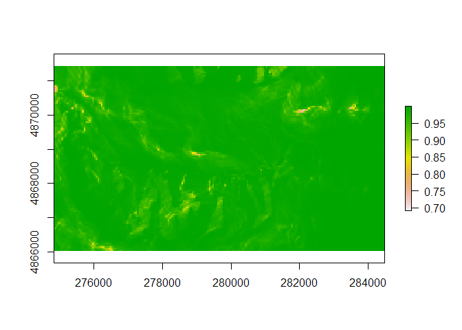

```r
landscapeValues$OvenOcc<-plogis(z$mean$lpsi+ # intercept
                z$mean$beta[1]*landscapeValues$Elevation+ #the elevation layer
                z$mean$beta[2]*(landscapeValues$Elevation*landscapeValues$Elevation) +  # mean Elev2
                z$mean$beta[3]*landscapeValues$Slope +  # mean Slope
                z$mean$beta[4]*landscapeValues$Aspect)  # mean Aspect

plot(rasterFromXYZ(cbind(landscapeValues$x,landscapeValues$y,landscapeValues$OvenOcc)))
```

## Variable selection

Model selection in a Bayesian framework is a bit controversial and the jury is still out, especially for hierarchical models. One way to determine variable importance is to use variable selection. It’s a rather neat trick and relatively simple to add to the model. Here we add a paramater $\gamma$ which takes a 1 if the variable is important and 0 otherwise. The more important a variable is the more times $\gamma$ will flip to 1. I’ve included the $\gamma$ parameter in the model specification below. Interpreting the $\beta$ estimates can be a little tricky because they go to 0 when $\gamma = 0$ and take the true value when $\gamma = 1$. Let’s have a look and implement it into the an occupancy model.

**Observation Model**

$y_{ij} \mid Z_i \sim Bern(Z_i*\rho_i)$

$logit(\rho_i) = \alpha + \gamma_1*\beta_1*Date_{ij}+\gamma_2*\beta_2*Time_{ij}+\gamma_3*\beta_3*Obs_{ij}$

**Process / Ecological Model**

$Z_i \sim Bern(\psi_i)$

$logit(\psi_i) = \alpha + \gamma_1*\beta_1*Elev_i + \gamma_2*\beta_2*Slope_i + \gamma_3*\beta_3*Aspect_i$

**Distribution of parameters in model**

$\beta \sim Norm(\mu,variance)$ $\alpha \sim Norm(\mu, variance)$ $\gamma \sim Bern(0.5)$

```r
###################################################################################
#
# Specify model in BUGS language
#
###################################################################################

cat("
model {
###################################################################################
#
#             Priors
#
###################################################################################
# Hyperpriors
mu.lpsi ~ dnorm(0,0.01)        # Intercept psi
sd.lpsi ~ dunif(0,8)           # std priro intercept psi
tau.lpsi <- pow(sd.lpsi, -2)   # precision intercept psi

mu.beta ~ dnorm(0,0.01)        # Prior for psi beta estimates
sd.beta ~ dunif(0,5)           # std for psi beta estimates
tau.beta <- pow(sd.beta, -2)   # precision psi beta estimates

mu.lp ~ dnorm(0,0.01)          # Intercept p
sd.lp ~ dunif(0,3)             # std prior p
tau.lp <- pow(sd.lp, -2)       # precision intercept p

mu.betaP ~ dnorm(0,0.01)       # Prior for p beta estimates
sd.betaP ~ dunif(0,3)          # std for p beta estimates
tau.betaP <- pow(sd.betaP, -2) # Precision for p beta estimates

# priors
   lpsi ~ dnorm(mu.lpsi, tau.lpsi) # Intercept for psi using Hyperparams
   lp ~ dnorm(mu.lp, tau.lp)       # Intercept for p using Hyperparams

for(c in 1:ncovs){                      # Occupancy Covs
   beta[c] ~ dnorm(mu.beta, tau.beta)   # prior for psi beta using hypers
   gamma[c] ~ dbern(0.5)                # variable selection
 } #ncovs

for(d in 1:pcovs){                       # Detection Covs
   betaP[d] ~ dnorm(mu.betaP, tau.betaP) # prior for p beta using hypers
   gammaP[d] ~ dbern(0.5)                # variable selection
}  #pcovs


##################################################################################
#
# Likelihood
# Ecological model for true occurrence (process model)
#
##################################################################################

for (i in 1:plots) {

      logit(psi[i])<-lpsi +              # intercept psi
                     gamma[1]*beta[1]*Elev[i] +   # beta for Elev
                     gamma[2]*beta[2]*Elev2[i] +  # beta for Elev2
                     gamma[3]*beta[3]*Slope[i] +  # beta for Slope
                     gamma[4]*beta[4]*Aspect[i]   # beta for Aspect

      z[i] ~ dbern(psi[i])               # Occupancy state

} #nplots

##################################################################################
#
# Observation model for replicated detection/nondetection observations
#
##################################################################################

   for (i in 1:plots){
      for(j in 1:reps){

         logit(p[i,j]) <-lp +                  # Intercept for detection
                         gammaP[1]*betaP[1]*time[i,j] +  # beta for time
                         gammaP[2]*betaP[2]*date[i,j] +  # beta for date
                         gammaP[3]*betaP[3]*obsvr[i,j]   # beta for observer

         y[i,j] ~ dbern(z[i] * p[i,j])    # True Occupancy state * detection

      } #nreps
   }    #nschwarz

##################################################################################
#
# Derived quantities
#
##################################################################################

# No derived quantities yet

##################################################################################

} # End Model
",fill=TRUE,file = "model_files/Occupancy_VariableSelection.txt")
```

```r
parameters.to.save = c("psi","lpsi","beta","gamma","p","lp","betaP","gammaP")
```

Next we send the model, data, and initial values to JAGS to run the analysis. Notice the different parameters that JAGS needs to run.

```r
a<-Sys.time()
z <- jags(model.file = "model_files/Occupancy_VariableSelection.txt",  # File written in BUGS language
          data = win.data,              # Data to run the model on
          inits = inits,                # initial values
          parameters.to.save = parameters.to.save,   # parameters you want to monitor
          n.iter = 1000,                # number of iterations to run per chain
          n.burnin = 500,               # number of iterations to discard
          n.thin = 10,                  # save every 10th iteration reduces autocorrelation
          n.chains = 3,                 # number of chains to run
          n.adapt = 500,                # number of iterations to 'prime' the model
          parallel = TRUE)              # run in parallel or not
```

```
##
## Processing function input.......
##
## Converting data frame 'y' to matrix.
##
## Converting data frame 'time' to matrix.
##
## Converting data frame 'date' to matrix.
##
## Converting data frame 'obsvr' to matrix.
##
## Done.
##
## Beginning parallel processing with 3 clusters. Console output will be suppressed.
##
## Parallel processing completed.
##
## Calculating statistics.......
##
## Done.
```

```r
Sys.time()-a
```

```
## Time difference of 33.37755 secs
```

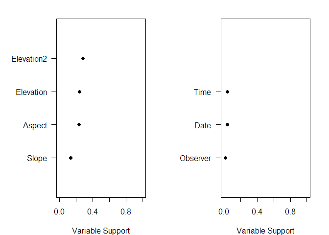

### Model Selection

We can get an idea of how many times the variables were in combination with one another to get at model selection.

```
##
##        Model Importance
##   0000          0.47333
##   0001          0.06000
##   0010          0.08667
##   0011          0.06667
##   0100          0.08667
##   0101          0.02000
##   0110          0.05333
##   0111          0.02000
##   1000          0.02000
##   1001          0.02667
##   1010          0.01333
##   1011          0.01333
##   1100          0.01333
##   1101          0.02000
##   1110          0.02000
##   1111          0.00667
```

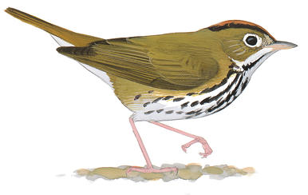

# Abundance

*Observation model*

$y_{ij} \mid N_i \sim Binomial(N_i,\rho)$

where $y$ is the observation of number of individuals at site $i$ and replcate $j$ given the true abundance ($N$) or population size at site $i$. $\rho$ is the probability of detecting an individual. *Note:* The meaning of detection probability is different here for abundance models. It might seem subtle but it’s actually very important that the detection is at the individual and not the species like occupancy models. We can model covariates on detection as well - the same as with the occupancy model above. We can model changes in expected abundance ($\lambda$) as function of covariates ($x$) using a linear model with a log link function.

$logit(\rho) = \alpha + \beta*x$

*Process model*

$N_i \sim Poisson(\lambda_i)$ $log(\lambda_i) = \alpha + \beta*x_i$

```r
#########################################################################################
#########################################################################################
#
#         Specify the model in BUGS language
#
#########################################################################################
#########################################################################################

cat("
model {
##########################################################################################
#
#  Priors

##########################################################################################
##### Hyperpriors #######
mu.theta ~ dnorm(0,0.01)
tau.theta ~ dgamma(0.001,0.001)
mu.thetaP ~ dnorm(0,0.01)
tau.thetaP ~ dgamma(0.001,0.001)

pInt ~ dnorm(0, 0.01)  # intercept for detection
alpha ~ dnorm(0,0.01)  # intercept for first count

for(i in 1:373){
Error[i]~dnorm(0,0.01)
}

# beta estimates
   for (c in 1:ncovs){
       beta[c]~dnorm(mu.theta,tau.theta)
       betaG[c]~dnorm(mu.theta,tau.theta)
      } #ncovs

# detection
for (m in 1:pcovs){
      betaP[m]~dnorm(mu.thetaP,tau.thetaP)
  } #pcovs

##########################################################################################
#
#  Likelihood
#
##########################################################################################
for(i in 1:plots) { # Plot
     N[i] ~ dpois(lambda[i])
     lambda[i]<-exp( alpha+                  #intercept
                       beta[1]*Elev[i]+        #Elevation
                       beta[2]*Slope[i]+       #Slope
                       beta[3]*Aspect[i]+      #Aspect
                       Error[i])               #Random Error term

   for(j in 1:reps) {                        # Replicates
     y[i,j] ~ dbin(p[i,j], N[i])
     p[i,j]<-1/(1+exp(-logit.p[i,j]))
     logit.p[i,j]<-pInt+                     # Detection intercept
                  betaP[1]*time[i,j]+        # time of count
                  betaP[2]*date[i,j]+        # date of count
                  betaP[3]*obsvr[i,j]        # observer who counted
     } #reps
} # plots
################################################################
#
# Derived parameters
#
################################################################
#
# Calculate the population size sampled at HBEF
#
  Ntot <- sum(N[])
 P <- mean(p[,])

} # END MODEL
",fill=TRUE,file="model_files/Abundance.txt")
```

Function to provide starting values for abundance model in JAGS. It’s common place to add 2 or more to the maximum number of birds observed at a site. If the model is run for enough iterations - this value has no impact on the final abundance estimates.

```r
Nst<-function(x){
     N<-apply(x,1,max,na.rm=TRUE)+2
     N[N==-Inf]<-NA
     N[is.na(N)]<-2
     return(N)
}
```

```r
win.data<-list(y = OVEN,
               Elev = SiteCovs$Elevation,
               Slope = SiteCovs$Slope,
               Aspect = SiteCovs$Aspect,
               date = Date,
               time = Time,
               obsvr = Obs,
               reps = 4,
               plots = 373,
               ncovs = 3,
               pcovs =3)
```

```r
inits<-function() list(mu.theta=0,
                       tau.theta=10,
                       mu.thetaP=0,
                       tau.thetaP=10,
                       N=Nst(OVEN))
```

Specify which parameters you want to monitor

```r
params<-c("N","Ntot","alpha","beta","betaP","Error","P")
```

Run the abundance model

```r
a<-Sys.time()
abundFit<-jags(model = "model_files/Abundance.txt",
               data = win.data,
               inits = inits,
               parameters.to.save = params,
               n.iter=1000,
                 n.burnin=500,
               n.thin=1,
               n.chains=3,
               n.adapt = 50,
               parallel = TRUE)
```

```
##
## Processing function input.......
##
## Converting data frame 'y' to matrix.
##
## Converting data frame 'date' to matrix.
##
## Converting data frame 'time' to matrix.
##
## Converting data frame 'obsvr' to matrix.
##
## Done.
##
## Beginning parallel processing with 3 clusters. Console output will be suppressed.
##
## Parallel processing completed.
##
## Calculating statistics.......
##
## Done.
```

```r
Sys.time()-a
```

```
## Time difference of 38.40372 secs
```

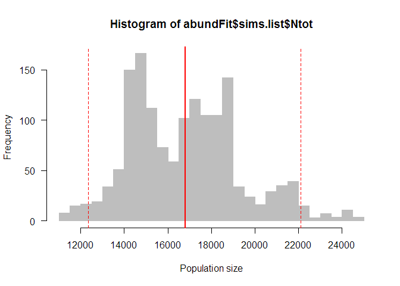

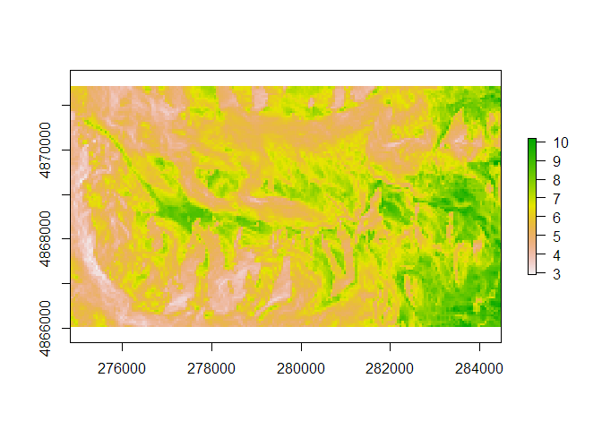

[figure not shown]